# Lake Erie Water Levels - A Time Series Analysis (Part 3/4)

### Step 7 - Forecasting into the Future

#### Retrain on Full Data

We will now retrain `SARIMA(2,1,1)(0,1,2,12)` model on full data.

```python
# Retrain on full dataset
SArima_Model = SARIMAX(erie_data['Erie'], order=(2,1,1), seasonal_order=(0,1,2,12))
SArima_results = SArima_Model.fit(solver='nm')
SArima_results.summary()
```

SARIMAX Results

| Dep. Variable: | Erie | No. Observations: | 1224 |
| --- | --- | --- | --- |
| Model: | SARIMAX(2, 1, 1)x(0, 1, [1, 2], 12) | Log Likelihood | 1624.208 |
| Date: | Sat, 29 Aug 2020 | AIC | -3236.416 |
| Time: | 14:32:48 | BIC | -3205.821 |
| Sample: | 01-01-1918 | HQIC | -3224.896 |
|  | - 12-01-2019 |  |  |
| Covariance Type: | opg |  |  |

|  | coef | std err | z | P>\|z\| | [0.025 | 0.975] |
| --- | --- | --- | --- | --- | --- | --- |
| ar.L1 | 1.0870 | 0.082 | 13.292 | 0.000 | 0.927 | 1.247 |
| ar.L2 | -0.2801 | 0.028 | -9.845 | 0.000 | -0.336 | -0.224 |
| ma.L1 | -0.8221 | 0.083 | -9.941 | 0.000 | -0.984 | -0.660 |
| ma.S.L12 | -0.9897 | 0.028 | -35.915 | 0.000 | -1.044 | -0.936 |
| ma.S.L24 | 0.0226 | 0.027 | 0.825 | 0.409 | -0.031 | 0.076 |
| sigma2 | 0.0039 | 0.000 | 31.470 | 0.000 | 0.004 | 0.004 |

| Ljung-Box (Q): | 33.83 | Jarque-Bera (JB): | 179.37 |
| --- | --- | --- | --- |
| Prob(Q): | 0.74 | Prob(JB): | 0.00 |
| Heteroskedasticity (H): | 0.94 | Skew: | 0.70 |
| Prob(H) (two-sided): | 0.56 | Kurtosis: | 4.26 |

Warnings:  
[1] Covariance matrix calculated using the outer product of gradients (complex-step).

#### Model Diagnostics

We will run model diagnostics to investigate any unusual behavior.

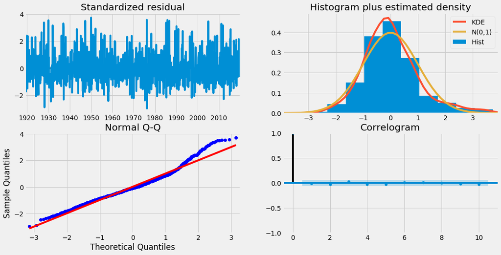

```python
with plt.style.context('fivethirtyeight'):
    SArima_results.plot_diagnostics(figsize=(16,8))
    plt.show()
```

> The properties of residuals should reflect the properties of underlying process. Model diagnostics suggests [5] that:
> 1. Residuals do not show a pattern
> 2. The ACF plot shows only 1st lag =1. All other lags are are small and within the confidence band.
> 3. Model residuals are near normally distributed.

*Top Right* : The density plot suggest normal distribution with mean zero.

*Bottom left* : All the dots should fall perfectly in line with some deviations towards the right implying skewed distribution.

*Bottom Right* : The Correlogram, aka, ACF plot shows the residual errors are not autocorrelated. Any autocorrelation would imply that there is some pattern in the residual errors which are not explained in the model.

#### Forecasting

We will forecast for 100 months into the future. Let's get the forecast results along with confidence intervals.

```python
pred_uc = SArima_results.get_forecast(steps=100)
print(pred_uc.summary_frame())
```

```
Erie              mean   mean_se  mean_ci_lower  mean_ci_upper
2020-01-01  174.701202  0.062352     174.578994     174.823409
2020-02-01  174.707747  0.100539     174.510694     174.904800
2020-03-01  174.801486  0.128087     174.550440     175.052532
2020-04-01  174.933769  0.148565     174.642586     175.224951
2020-05-01  175.009094  0.164523     174.686636     175.331553
...                ...       ...            ...            ...
2027-12-01  174.833991  0.631710     173.595862     176.072120
2028-01-01  174.854735  0.635743     173.608702     176.100769
2028-02-01  174.860574  0.639811     173.606568     176.114580
2028-03-01  174.953194  0.643854     173.691264     176.215125
2028-04-01  175.086617  0.647856     173.816842     176.356392

[100 rows x 4 columns]
```

##### Plot Forecasts

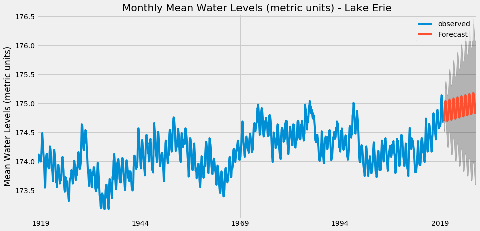

```python
with plt.style.context('fivethirtyeight'):
    title = 'Monthly Mean Water Levels (metric units) - Lake Erie'
    ylabel='Mean Water Levels (metric units)'

    pred_ci = pred_uc.conf_int() #get confidence interval
    ax = erie_data['Erie'].plot(label='observed', figsize=(14, 7),title=title)
    pred_uc.predicted_mean.plot(ax=ax, label='Forecast') #plot predictions
    ax.fill_between(pred_ci.index,
                    pred_ci.iloc[:, 0],
                    pred_ci.iloc[:, 1], color='k', alpha=.25)
    ax.set_xlabel('')
    ax.set(ylabel=ylabel)
    plt.legend()
    plt.show()
```

Let's zoom into the forecast time period to understand the trend and seasonality of the forecasts.

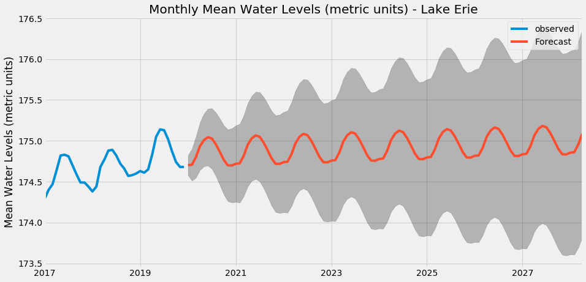

```python
with plt.style.context('fivethirtyeight'):
    title = 'Monthly Mean Water Levels (metric units) - Lake Erie'
    ylabel='Mean Water Levels (metric units)'

    pred_ci = pred_uc.conf_int() #get confidence interval
    ax = erie_data['01-01-2017':]['Erie'].plot(label='Observed', figsize=(14, 7),title=title)
    pred_uc.predicted_mean.plot(ax=ax, label='Forecast') #plot predictions
    ax.fill_between(pred_ci.index,
                    pred_ci.iloc[:, 0],
                    pred_ci.iloc[:, 1], color='k', alpha=.25)
    ax.set_xlabel('')
    ax.set(ylabel=ylabel)
    plt.legend()
    plt.show()
```

> Our model clearly captured seasonality and trend in water levels. The forecasts show some consistency in trend with water levels not increasing as sharply as they has been for the last few years. As we forecast further out into the future, it is natural for us to become less confident in our values. This is reflected by the confidence intervals generated by our model, which grow larger as we move further out into the future.

## Summary

To summarize, in this notebook we:

1. Read Lake Erie water level data and indexed it as a time series.
2. Checked stationarity of data.
3. Seasonally and Non-seasonally differenced the data to make it stationary.
4. Used the ACF and PACF plots to decide AR term(s) and MA term(s).
5. Identified optimal SARIMA order using grid search and both Seasonal, Non-seasonal differencing .
6. Split the data, built and fit optimal SARIMA model on the data.
7. Validated model performance.
8. Performed forecasting for future periods.

We have seen that **SARIMA(2,1,1)(0,1,2,12)** model is the best model as it captures the trend and seasonality of data well and has the lowest RMSE. The model forecasts show consistency in trend with water levels not increasing as sharply as they has been for the last few years. As we forecast into the future, we become less confident in our values as reflected by the confidence intervals generated by our model, which grow larger as we move further out into the future.

So far, we have looked at water level data for Lake Erie and tried to forecast water levels into the future. Factors such as precipitation, air temperature, snow cover etc. can also impact the amount of water levels in Lake Erie. To consider these other variables for forecasting water levels, we will look at Vector based modeing techniques such as **Vector AutoRegressive Moving Average (VARMA) Models** in the next part of this study.

## References

[1] https://faculty.fuqua.duke.edu/~rnau/Decision411_2007/seasarim.htm  
[2] https://online.stat.psu.edu/stat510/lesson/4/4.1  
[3] Hyndman, Rob J. & Athanasopoulos, George. & OTexts.com, issuing body. (2014). Forecasting : principles and practice. [Heathmont?, Victoria] : https://otexts.com/fpp2/  
[4] https://faculty.fuqua.duke.edu/~rnau/Decision411_2007/seasarim.htm  
[5] Serban, N. (2018). Unit 2: Auto Regressive and Moving Average (ARMA) Model [Lecture Recording]. Georgia Institute of Technology. https://omscs.gatech.edu/isye-6402-time-series-analysis